# Practical Machine Learning Assignment

Pinja Haikka

8/31/2017

We study how raw data on performing wieght lifitng exercise predicts how well the exercise was executed. In our dataset, downloaded from http://web.archive.org/web/20161224072740/http:/groupware.les.inf.puc-rio.br/har, variable ‘classe’ denotes how well the exercise was executed, with A representing a perfect executing and B-E representing common mistakes.

First download the R packages used in this report.

```r
library(caret) # for running the classification algorithm
library(plyr); library(dplyr) # for data handling
library(ggplot2) # for plotting
library(reshape2) # for plotting
```

Next download the training and testing datasets and transform ‘classe’ into a categorical variable.

```r
# load data
training <- read.csv('pml-training.csv', stringsAsFactors = FALSE)
testing <- read.csv('pml-testing.csv', stringsAsFactors = FALSE)
# class to predict
training$classe <- as.factor(training$classe)
```

The datasets need to be cleaned before building the predictive algorithm. First we remove remove the first columns that include information on names, timestamps etc.

```r
training <- training[, -c(1:7)]
testing <- testing[, -c(1:7)]
```

We observe that the data frames contain many missing variables. Some of the data is imported as characters, including entries like “#DIV/0!”, and otherwise contaning predomonantly missing values. We identify and remove these variables.

```r
# identify character columns
chrCols <- sapply(training, is.character)
# check what fraction is empty entries
colSums(training[, chrCols] == '')/nrow(training)
```

```
##      kurtosis_roll_belt     kurtosis_picth_belt       kurtosis_yaw_belt
##               0.9793089               0.9793089               0.9793089
##      skewness_roll_belt    skewness_roll_belt.1       skewness_yaw_belt
##               0.9793089               0.9793089               0.9793089
##            max_yaw_belt            min_yaw_belt      amplitude_yaw_belt
##               0.9793089               0.9793089               0.9793089
##       kurtosis_roll_arm      kurtosis_picth_arm        kurtosis_yaw_arm
##               0.9793089               0.9793089               0.9793089
##       skewness_roll_arm      skewness_pitch_arm        skewness_yaw_arm
##               0.9793089               0.9793089               0.9793089
##  kurtosis_roll_dumbbell kurtosis_picth_dumbbell   kurtosis_yaw_dumbbell
##               0.9793089               0.9793089               0.9793089
##  skewness_roll_dumbbell skewness_pitch_dumbbell   skewness_yaw_dumbbell
##               0.9793089               0.9793089               0.9793089
##        max_yaw_dumbbell        min_yaw_dumbbell  amplitude_yaw_dumbbell
##               0.9793089               0.9793089               0.9793089
##   kurtosis_roll_forearm  kurtosis_picth_forearm    kurtosis_yaw_forearm
##               0.9793089               0.9793089               0.9793089
##   skewness_roll_forearm  skewness_pitch_forearm    skewness_yaw_forearm
##               0.9793089               0.9793089               0.9793089
##         max_yaw_forearm         min_yaw_forearm   amplitude_yaw_forearm
##               0.9793089               0.9793089               0.9793089
```

```r
# character columns are mostly empty data >>> discard them
training <- training[, !chrCols]
testing <- testing[, !chrCols]
```

With the remaining data we still observe that many variables only contain NAs, and discard all variables with over 50% missing values.

```r
# check what fraction is NAs
colSums(is.na(training))/nrow(training)
```

```
##                roll_belt               pitch_belt                 yaw_belt
##                0.0000000                0.0000000                0.0000000
##         total_accel_belt            max_roll_belt           max_picth_belt
##                0.0000000                0.9793089                0.9793089
##            min_roll_belt           min_pitch_belt      amplitude_roll_belt
##                0.9793089                0.9793089                0.9793089
##     amplitude_pitch_belt     var_total_accel_belt            avg_roll_belt
##                0.9793089                0.9793089                0.9793089
##         stddev_roll_belt            var_roll_belt           avg_pitch_belt
##                0.9793089                0.9793089                0.9793089
##        stddev_pitch_belt           var_pitch_belt             avg_yaw_belt
##                0.9793089                0.9793089                0.9793089
##          stddev_yaw_belt             var_yaw_belt             gyros_belt_x
##                0.9793089                0.9793089                0.0000000
##             gyros_belt_y             gyros_belt_z             accel_belt_x
##                0.0000000                0.0000000                0.0000000
##             accel_belt_y             accel_belt_z            magnet_belt_x
##                0.0000000                0.0000000                0.0000000
##            magnet_belt_y            magnet_belt_z                 roll_arm
##                0.0000000                0.0000000                0.0000000
##                pitch_arm                  yaw_arm          total_accel_arm
##                0.0000000                0.0000000                0.0000000
##            var_accel_arm             avg_roll_arm          stddev_roll_arm
##                0.9793089                0.9793089                0.9793089
##             var_roll_arm            avg_pitch_arm         stddev_pitch_arm
##                0.9793089                0.9793089                0.9793089
##            var_pitch_arm              avg_yaw_arm           stddev_yaw_arm
##                0.9793089                0.9793089                0.9793089
##              var_yaw_arm              gyros_arm_x              gyros_arm_y
##                0.9793089                0.0000000                0.0000000
##              gyros_arm_z              accel_arm_x              accel_arm_y
##                0.0000000                0.0000000                0.0000000
##              accel_arm_z             magnet_arm_x             magnet_arm_y
##                0.0000000                0.0000000                0.0000000
##             magnet_arm_z             max_roll_arm            max_picth_arm
##                0.0000000                0.9793089                0.9793089
##              max_yaw_arm             min_roll_arm            min_pitch_arm
##                0.9793089                0.9793089                0.9793089
##              min_yaw_arm       amplitude_roll_arm      amplitude_pitch_arm
##                0.9793089                0.9793089                0.9793089
```

[output cut: 25 more lines]

```
##                0.9793089                0.9793089                0.9793089
##      total_accel_forearm        var_accel_forearm         avg_roll_forearm
##                0.0000000                0.9793089                0.9793089
##      stddev_roll_forearm         var_roll_forearm        avg_pitch_forearm
##                0.9793089                0.9793089                0.9793089
##     stddev_pitch_forearm        var_pitch_forearm          avg_yaw_forearm
##                0.9793089                0.9793089                0.9793089
##       stddev_yaw_forearm          var_yaw_forearm          gyros_forearm_x
##                0.9793089                0.9793089                0.0000000
##          gyros_forearm_y          gyros_forearm_z          accel_forearm_x
##                0.0000000                0.0000000                0.0000000
##          accel_forearm_y          accel_forearm_z         magnet_forearm_x
##                0.0000000                0.0000000                0.0000000
##         magnet_forearm_y         magnet_forearm_z                   classe
##                0.0000000                0.0000000                0.0000000
```

```r
# remove the ones where over 50% is NAs
removeNA <- colSums(is.na(training))/nrow(training) > 0.5
training <- training[, !removeNA]
testing <- testing[, !removeNA]
```

The data frames, which now consist of 52 predictors and the class to be predicted, no longer contain missing values.

```r
table(complete.cases(training))
```

```
##
##  TRUE
## 19622
```

We next do a visual inspection of the data. First check how balanced the classes are in the training set.

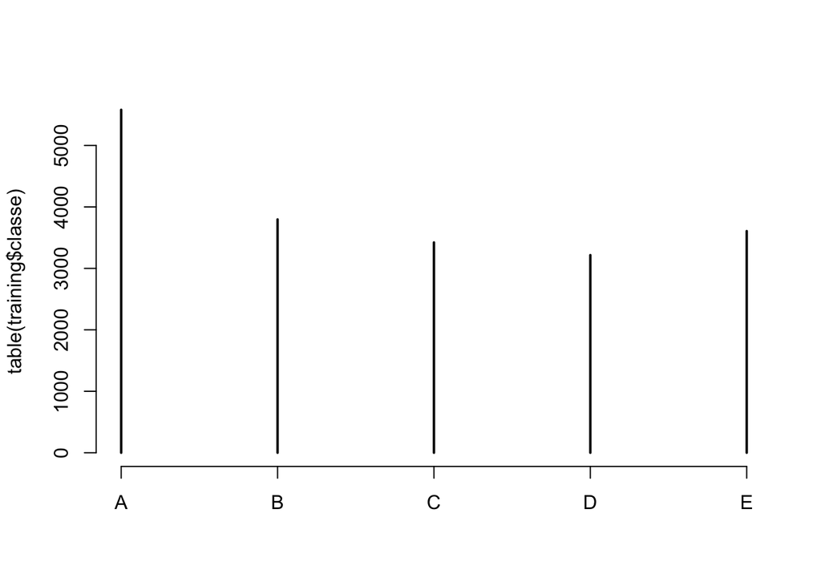

```r
plot(table(training$classe))
```

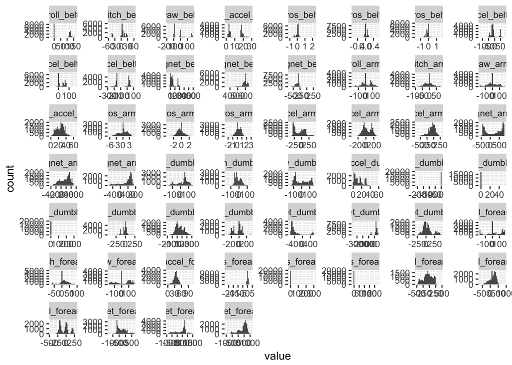

```r
df <- melt(training, variable.name = 'predictors')
ggplot(df, aes(value)) + geom_histogram() + facet_wrap(~ predictors, scales = 'free')
```

Plotting the predictors reveals that some of them (gyros_forearm_y/z, gyros_dumbbell_x/y/z) are very skewed. A close inspection shows that this is due to one observation having values that are orders or magnitude away from all other observations.

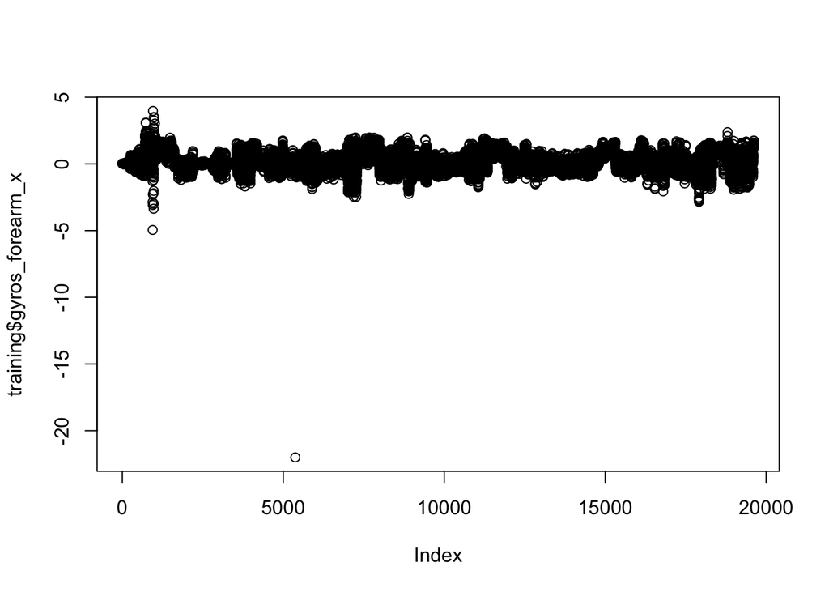

```r
plot(training$gyros_forearm_x)
```

This outlier is likely due to a bug or a human error in the recording of the values, and since it is only a single observation, we remove it from the dataset.

```r
# identify and remove this outlier
outlier <- which(training$gyros_forearm_x < -10)
training <- training[-outlier, ]
```

After removing the outlier observation all predictors look well balanced.

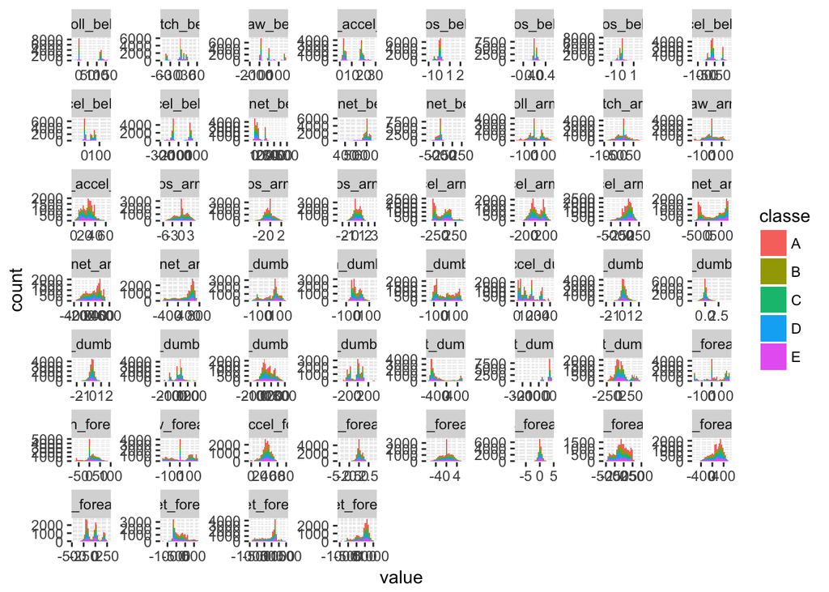

```r
df <- melt(training, variable.name = 'predictors')
ggplot(df, aes(value, fill = classe)) + geom_histogram() + facet_wrap(~ predictors, scales = 'free')
```

```r
predInSample <- predict(fit.gbm)
confusionMatrix(predInSample, training$classe)
```

```
## Confusion Matrix and Statistics
##
##           Reference
## Prediction    A    B    C    D    E
##          A 5522   88    0    1    5
##          B   40 3636   87    7   22
##          C   11   71 3300   95   26
##          D    4    1   29 3096   40
##          E    2    1    6   17 3514
##
## Overall Statistics
##
##                Accuracy : 0.9718
##                  95% CI : (0.9694, 0.9741)
##     No Information Rate : 0.2843
##     P-Value [Acc > NIR] : < 2.2e-16
##
##                   Kappa : 0.9643
##  Mcnemar's Test P-Value : < 2.2e-16
##
## Statistics by Class:
##
##                      Class: A Class: B Class: C Class: D Class: E
## Sensitivity            0.9898   0.9576   0.9643   0.9627   0.9742
## Specificity            0.9933   0.9901   0.9875   0.9955   0.9984
## Pos Pred Value         0.9833   0.9589   0.9420   0.9767   0.9927
## Neg Pred Value         0.9959   0.9898   0.9924   0.9927   0.9942
## Prevalence             0.2843   0.1935   0.1744   0.1639   0.1838
## Detection Rate         0.2814   0.1853   0.1682   0.1578   0.1791
## Detection Prevalence   0.2862   0.1933   0.1785   0.1616   0.1804
## Balanced Accuracy      0.9915   0.9739   0.9759   0.9791   0.9863
```

```r
cv.predictions <- fit.gbm$pred
# check the results of the final model only
cv.predictions.final <- filter(cv.predictions, n.trees == 150, interaction.depth == 3, shrinkage == 0.1)
# caculate the accuracy of each fold
cv.acc <- ddply(cv.predictions.final, "Resample", summarise, acc = sum(pred == obs)/length(pred))
# and from that the mean and standard deviation of the accuracy
mean(cv.acc$acc)
```

```
## [1] 0.9624889
```

```r
sd(cv.acc$acc)
```

```
## [1] 0.002628929
```

```r
predict(fit.gbm, testing)
```

```
##  [1] B A B A A E D B A A B C B A E E A B B B
## Levels: A B C D E
```